# Data Visualization Portfolio

Author

D’Angelo Francis

## Visualization 1: Broadband Infrastructure and Foreign Direct Investment in the Carribean

### Purpose

The purpose of this visualization is to demonstrate the benefit of net foreign direct investment (FDI) in expanding access to broadband internet in the Caribbean. Specifically, I am exploring the relationship between FDI net inflow and broadband access[^1] from 2013-2023 with respect to Hispaniola (Haiti and the Dominican Republic. I want the end user to observe the stark difference between Haiti and the Dominican Republic despite being neighbors on the same island.

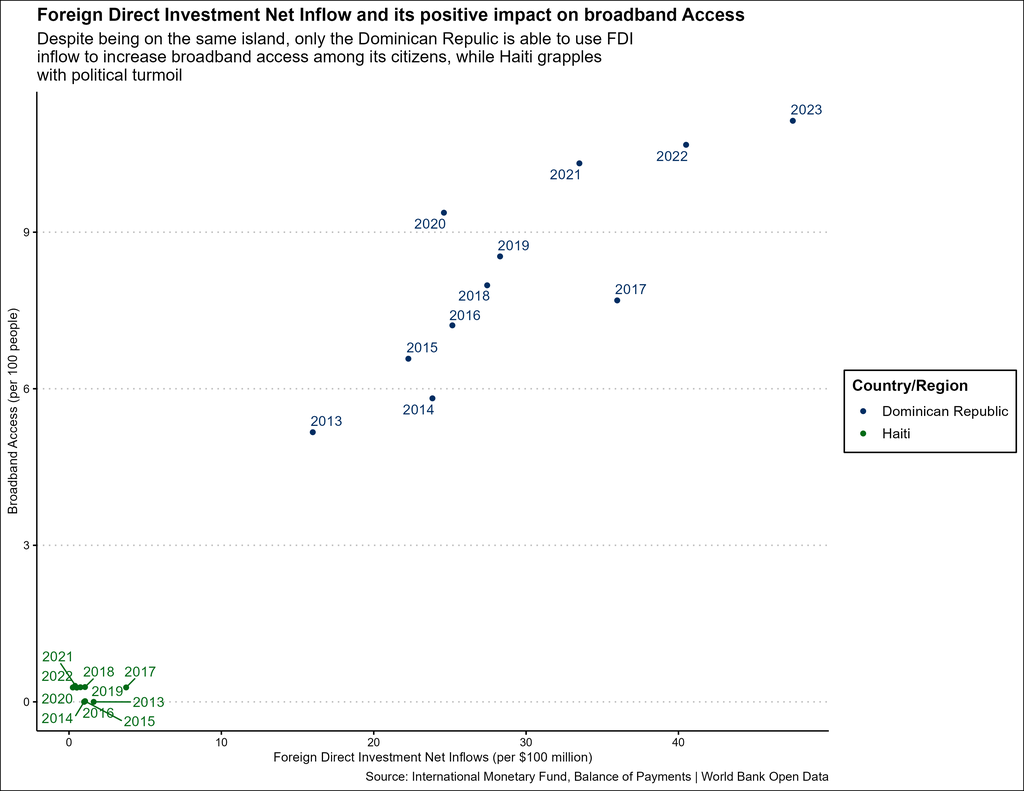

## Visualization 2: Japan’s railroad infrastructure and its relationship with Gross Regional Domestic Product (GRDP)

### Purpose

The purpose behind this visualization is to emphasis how railroad investment contributes to economic success. Japan has an extensive network of both private and government-owned railroads[^2] that efficiently ships foreign imports from the major ports of Japan and ferry commuters between the office and their home. Japan’s high-speed rail system—the *shinkansen*, is vaunted for its ability to travel between major cities while maintaining superb passenger comfort and boosting regional economic growth.[^3]

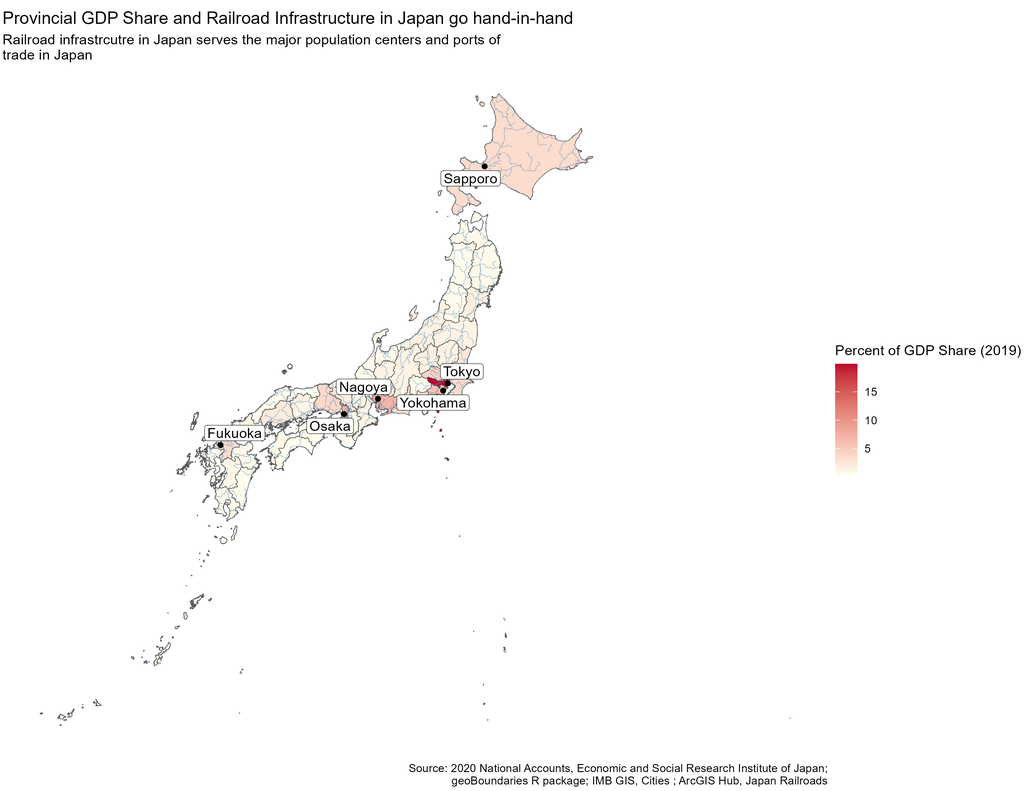

Plot of Japanese Rail and GDP by Region

## Visualization 3: One ‘Rail’ to Rule Them All: MTA Domination: 2002 - 2023

### Purpose

The purpose of this visualization is to visualize the monopolization of commuter rail by New York’s Metropolitan Transportation Agency (MTA) and its sustained dominance over the commuter service of New Jersey Transit (NJ Transit) and the Port Authority Trans-Hudson Corporation (PATH).

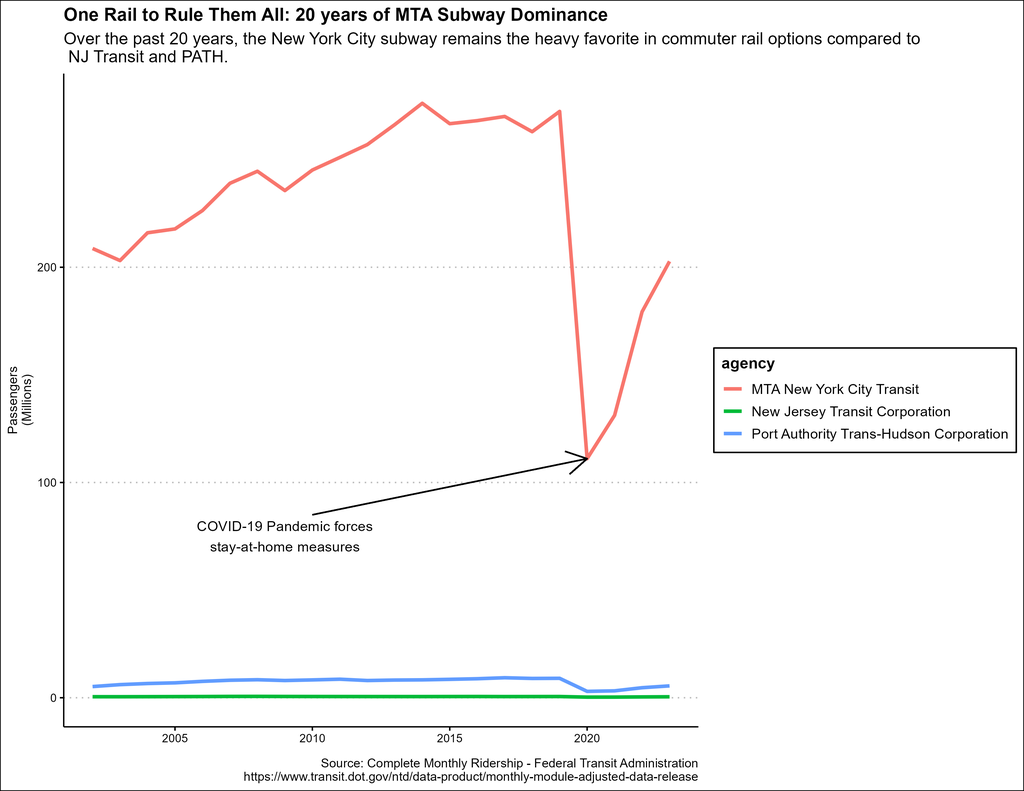

MTA Ridership 2002 - 2023

## Visualization 4: ‘Debt and Taxes’: The Two Guarantees of Public Transportation

### Purpose

The purpose behind this visualization is to cement the point that public, government-operated transport is often run at a loss in metropolitan areas—especially after the COVID-19 pandemic. On one hand, the business model of government-run public transport is what keeps *all* the citizens on major metropolitan areas moving and reduces the amount of cars of the street. On the other hand, the troubling lack of investment in public transportation in addition to increasing expenses continues to hamper the safety, resilience, and existence of public transport.

Notably, the Washington Metropolitan Area Transportation Authority leads the pack in debt with over $200 million dollars.[^4] This hits close to home, as I—as well as hundreds of thousands of other people—rely on WMATA to visit Northern Virginia and Maryland.

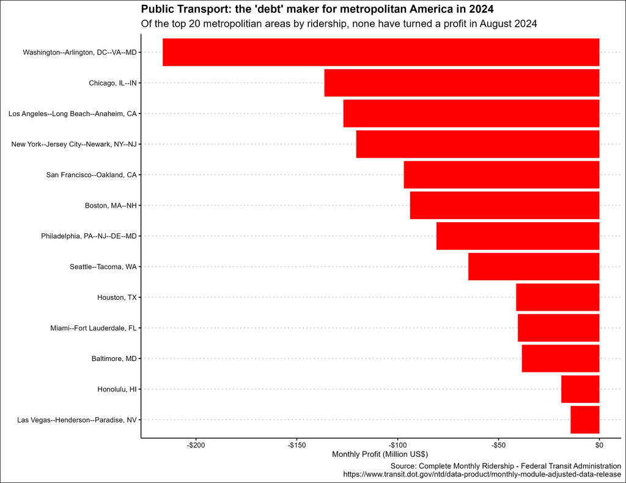

## Vizualization 5: China’s Special Economic Zones

### Purpose

The purpose of this visualization is to explore the spatial economics of China’s Special Economic Zones or SEZs. These areas benefit from relaxed regulation and government assistance in the form of subsides, tax breaks, or even direct government intervention.[^5]

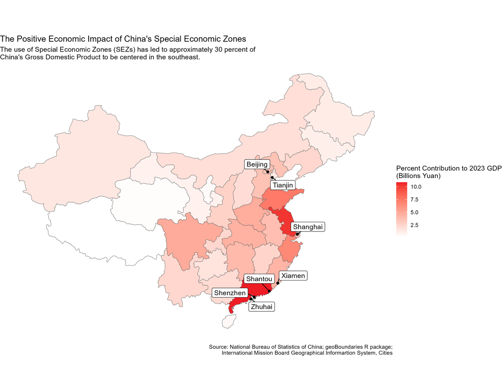

## Visualization 6

### Purpose

The purpose of this visualization is to further explore the effect that special economic zones may have on provincial level gross domestic product in China over time since 1992.

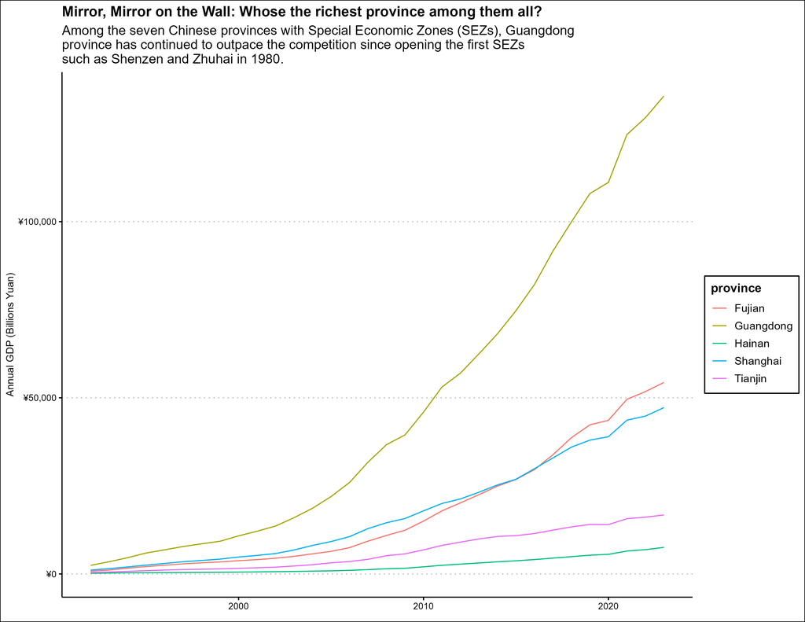

## Visualization 7

### Purpose

The purpose of this visualization is to explore what CHIPS (**C**reating **H**elpful **I**ncentives to **P**roduce **S**emiconductors) Act funding is going toward in regard to building infrastructure for domestic semiconductor production.

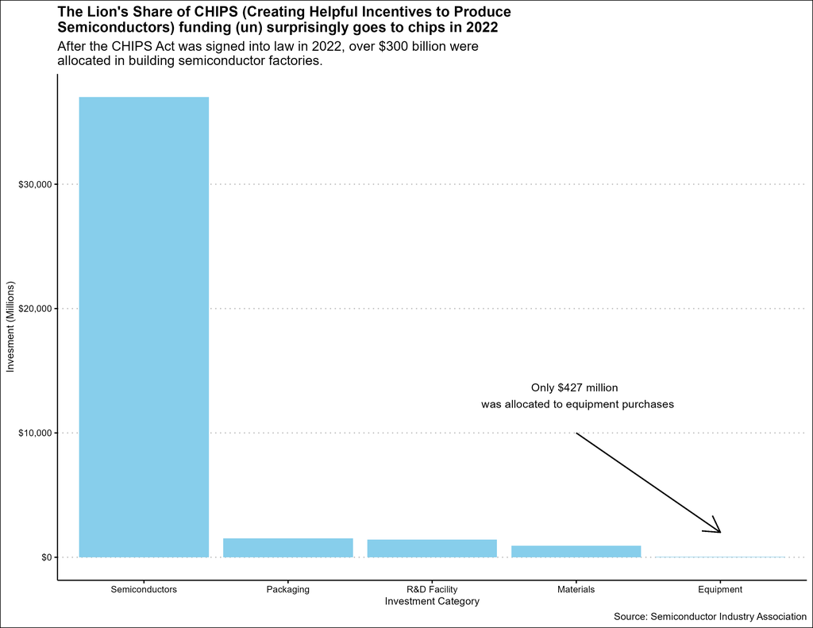

## Visualization 8

### Purpose

The purpose of this visualization is to look at investment amount compared to expected job openings for semiconductor firms that have announced receiving funding through the CHIPS Act.

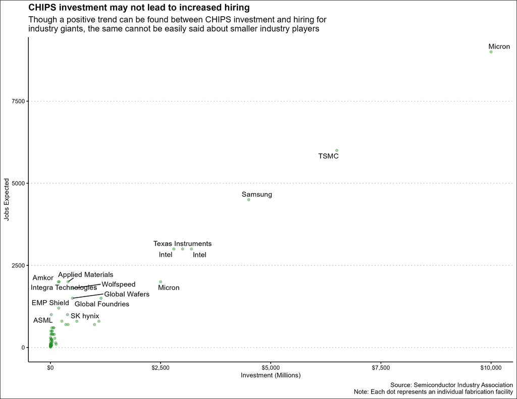

Scatter Plot of CHIPS investment and expected jobs

## Footnotes

[^1]: Fixed broadband subscriptions refers to fixed subscriptions to high-speed access to the public Internet downstream speeds equal to, or greater than, 256 kbit/s. This includes cable modem, DSL, fiber-to-the-home/building, other fixed (wired)-broadband subscriptions, satellite broadband and terrestrial fixed wireless broadband. It *excludes* subscriptions that have access to data communications via mobile-cellular networks.
[^2]: Japan Private Railway Association, [*Introduction of Private Railway Companies*](https://www.mintetsu.or.jp/en/index.html)
[^3]: Government of Japan, [*The Shinkansen, Japan’s High-Speed Rail, Is Full of Miracles*](https://www.japan.go.jp/tomodachi/2014/autumn2014/the_shinkansen_japans_high-speed_rail.html)
[^4]: Laris, M; [*Billion-dollar deficits, drastic cuts: Metro faces fiscal catastrophe*](https://www.washingtonpost.com/dc-md-va/2024/08/09/metro-financial-crisis/); The Washington Post, August 2024
[^5]: Zeng, D.;*China’s Special Economic Zones and Industrial Clusters: Success and Challenges*; Lincoln Institute of Land Policy 2012